# Practical Machine Learning Assignment

Wong Thai Min

December 26, 2015

## Background

Using devices such as Jawbone Up, Nike FuelBand, and Fitbit it is now possible to collect a large amount of data about personal activity relatively inexpensively. These type of devices are part of the quantified self movement – a group of enthusiasts who take measurements about themselves regularly to improve their health, to find patterns in their behavior, or because they are tech geeks. One thing that people regularly do is quantify how much of a particular activity they do, but they rarely quantify how well they do it. In this project, the goal is to use data from accelerometers on the belt, forearm, arm, and dumbell of 6 participants. They were asked to perform barbell lifts correctly and incorrectly in 5 different ways. More information is available from the website here: http://groupware.les.inf.puc-rio.br/har (see the section on the Weight Lifting Exercise Dataset).

## Prepare the data

```r
options(warn=-1)
download.file(url = "https://d396qusza40orc.cloudfront.net/predmachlearn/pml-training.csv", destfile = "pml-training.csv", method = "curl")
download.file(url = "https://d396qusza40orc.cloudfront.net/predmachlearn/pml-testing.csv", destfile = "pml-testing.csv", method = "curl")
train_data <- read.table("pml-training.csv", header = TRUE, sep = ",", na.strings = c("NA",""))
test_data <- read.table("pml-testing.csv", header = TRUE, sep = ",", na.strings = c("NA",""))
```

## Data Cleansing

Extract only the eligible predictors by:

1. Filter out variables with NA values.
2. Filter out non-measurement variables from accerelometers.

```r
isNA <- sapply(train_data, function(x) any(is.na(x)))
isPredictor <- grepl("belt|arm|dumbbell|classe", names(train_data))
train_data <- train_data[, !isNA & isPredictor]
```

## Data slicing

Perform cross validation by splitting the training data into 60% train sets and 40% test sets.

```r
library(caret)
inTrain <- createDataPartition(y = train_data$classe, p = 0.6, list = FALSE)
training <- train_data[inTrain,]
testing <- train_data[-inTrain,]
dim(training); dim(testing)
```

```
## [1] 11776    53
```

```
## [1] 7846   53
```

## Prediction Model: Decision Trees (rpart algorithm)

We try to use “rpart” algorithm from caret package to train a Decision Trees prediction model.

```r
modFit <- train(classe ~ ., data = training, method = "rpart")
print(modFit$finalModel)
```

```
## n= 11776
##
## node), split, n, loss, yval, (yprob)
##       * denotes terminal node
##
##  1) root 11776 8428 A (0.28 0.19 0.17 0.16 0.18)
##    2) roll_belt< 130.5 10790 7451 A (0.31 0.21 0.19 0.18 0.11)
##      4) pitch_forearm< -33.95 946    4 A (1 0.0042 0 0 0) *
##      5) pitch_forearm>=-33.95 9844 7447 A (0.24 0.23 0.21 0.2 0.12)
##       10) magnet_dumbbell_y< 426.5 8208 5876 A (0.28 0.18 0.24 0.19 0.11)
##         20) roll_forearm< 122.5 5111 3018 A (0.41 0.18 0.18 0.17 0.062) *
##         21) roll_forearm>=122.5 3097 2035 C (0.077 0.18 0.34 0.23 0.18) *
##       11) magnet_dumbbell_y>=426.5 1636  828 B (0.04 0.49 0.044 0.23 0.19) *
##    3) roll_belt>=130.5 986    9 E (0.0091 0 0 0 0.99) *
```

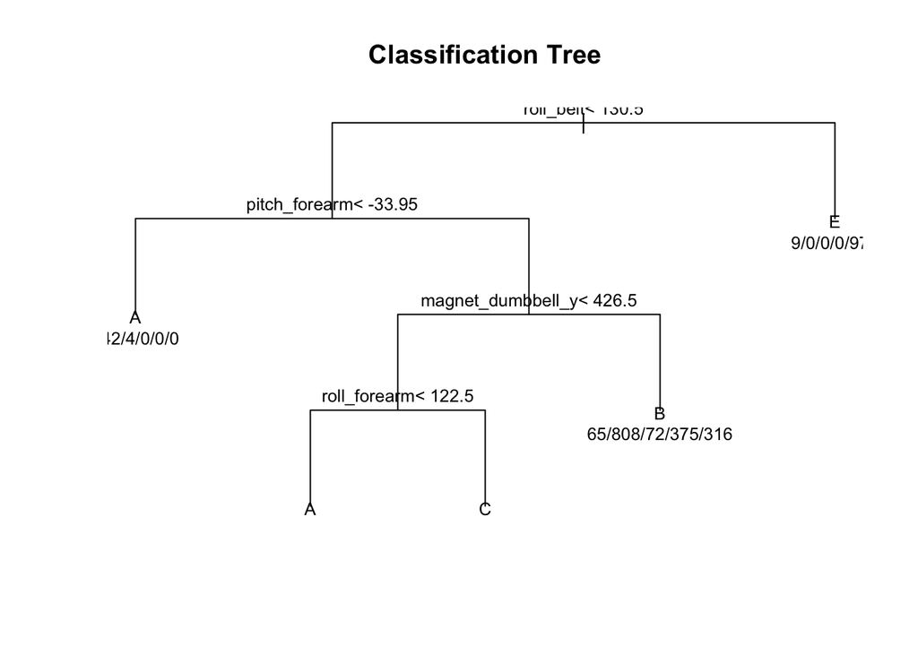

```r
plot(modFit$finalModel, uniform=TRUE, main="Classification Tree")
text(modFit$finalModel, use.n=TRUE, cex=.8)
```

```r
results <- predict(modFit, newdata = testing)
confusionMatrix(results, testing$classe)
```

```
## Confusion Matrix and Statistics
##
##           Reference
## Prediction    A    B    C    D    E
##          A 2008  591  648  558  178
##          B   58  540   57  241  214
##          C  161  387  663  487  396
##          D    0    0    0    0    0
##          E    5    0    0    0  654
##
## Overall Statistics
##
##                Accuracy : 0.4926
##                  95% CI : (0.4815, 0.5037)
##     No Information Rate : 0.2845
##     P-Value [Acc > NIR] : < 2.2e-16
##
##                   Kappa : 0.3378
##  Mcnemar's Test P-Value : NA
##
## Statistics by Class:
##
##                      Class: A Class: B Class: C Class: D Class: E
## Sensitivity            0.8996  0.35573   0.4846   0.0000  0.45354
## Specificity            0.6482  0.90992   0.7791   1.0000  0.99922
## Pos Pred Value         0.5041  0.48649   0.3166      NaN  0.99241
## Neg Pred Value         0.9420  0.85481   0.8774   0.8361  0.89036
## Prevalence             0.2845  0.19347   0.1744   0.1639  0.18379
## Detection Rate         0.2559  0.06882   0.0845   0.0000  0.08335
## Detection Prevalence   0.5076  0.14147   0.2669   0.0000  0.08399
## Balanced Accuracy      0.7739  0.63283   0.6319   0.5000  0.72638
```

## Prediction Model: Random Forest

We try to use Random Forest algorithm to train a Decision Trees prediction model.

```r
library(randomForest)
modFit_RF <- randomForest(classe ~ ., data = training)
print(modFit_RF)
```

```
##
## Call:
##  randomForest(formula = classe ~ ., data = training)
##                Type of random forest: classification
##                      Number of trees: 500
## No. of variables tried at each split: 7
##
##         OOB estimate of  error rate: 0.66%
## Confusion matrix:
##      A    B    C    D    E  class.error
## A 3346    1    0    0    1 0.0005973716
## B   13 2262    4    0    0 0.0074594120
## C    0   20 2031    3    0 0.0111976631
## D    1    0   27 1900    2 0.0155440415
## E    0    0    1    5 2159 0.0027713626
```

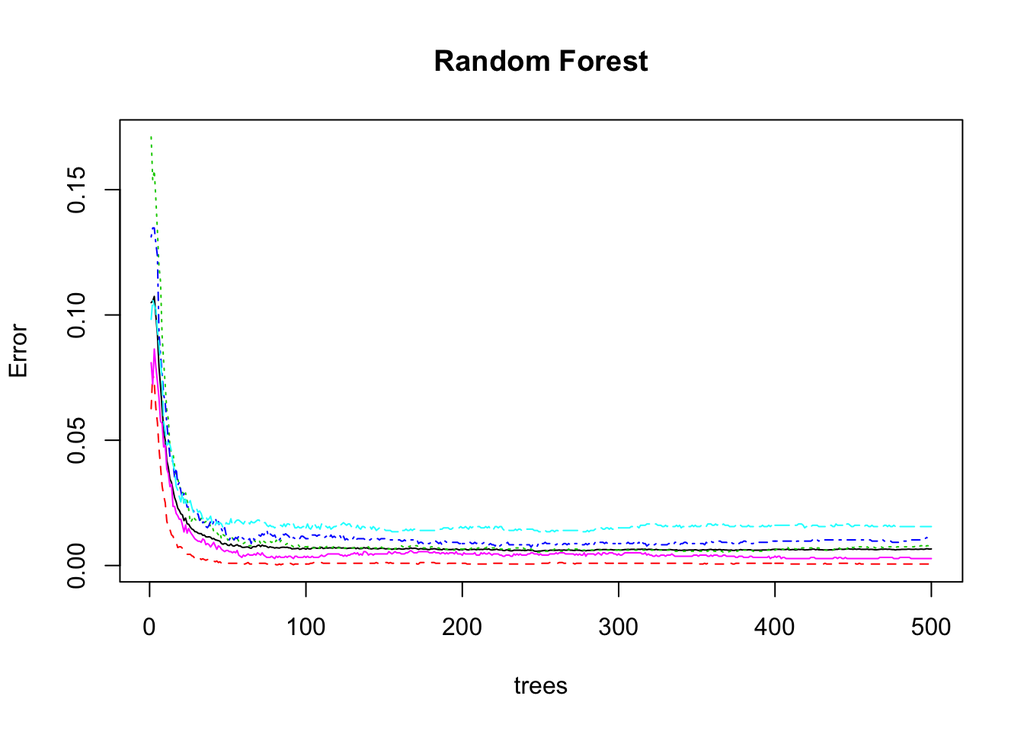

```r
plot(modFit_RF, uniform=TRUE, main="Random Forest")
```

Obviously, the error rate has significant reduced when the number of trees has grown approximately >= 50.

```r
results_RF <- predict(modFit_RF, newdata = testing)
confusionMatrix(results_RF, testing$classe)
```

```
## Confusion Matrix and Statistics
##
##           Reference
## Prediction    A    B    C    D    E
##          A 2225   13    0    0    0
##          B    7 1504    8    0    0
##          C    0    1 1353   15    0
##          D    0    0    7 1270    7
##          E    0    0    0    1 1435
##
## Overall Statistics
##
##                Accuracy : 0.9925
##                  95% CI : (0.9903, 0.9943)
##     No Information Rate : 0.2845
##     P-Value [Acc > NIR] : < 2.2e-16
##
##                   Kappa : 0.9905
##  Mcnemar's Test P-Value : NA
##
## Statistics by Class:
##
##                      Class: A Class: B Class: C Class: D Class: E
## Sensitivity            0.9969   0.9908   0.9890   0.9876   0.9951
## Specificity            0.9977   0.9976   0.9975   0.9979   0.9998
## Pos Pred Value         0.9942   0.9901   0.9883   0.9891   0.9993
## Neg Pred Value         0.9988   0.9978   0.9977   0.9976   0.9989
## Prevalence             0.2845   0.1935   0.1744   0.1639   0.1838
## Detection Rate         0.2836   0.1917   0.1724   0.1619   0.1829
## Detection Prevalence   0.2852   0.1936   0.1745   0.1637   0.1830
## Balanced Accuracy      0.9973   0.9942   0.9933   0.9927   0.9975
```

This time, all the activities (classe) could be predicted and the accuracy is very high > 99%.

## Conclusion

Random Forest is chosen because it has performed as a much stronger prediction model due to its bagging algorithms that boosted the prediction accuracy significantly.

```r
answers <- predict(modFit_RF, newdata = test_data)
source("pml_write_files.R")
pml_write_files(answers)
```